# The K-Shaped Economy: A Tale of Two Americas

An interactive exploration of inflation and wealth

Author

German Juarez

## Part 1: The Headline Economy

If we judge the health of the economy purely by the stock market, we are living in a historic golden age.

Since 2016, despite a brief, sharp drop during the early days of the global pandemic, the S&P 500 has surged to record breaking heights. This upward trajectory dominates media and financial headlines, driving the narrative of a robust, thriving American economy.

But the stock market is not the economy. And for a vast portion of Americans, this massive generation of wealth is happening entirely out of reach.

[figure not shown]

## Part 2: The Illusion of Relief

While the stock market boomed, there was another historic event: the inflation crisis of 2021 and 2022.

However, a falling inflation rate is a misleading metric of relief. Disinflation does not mean prices are dropping. It simply means prices are rising at a slower pace. The damage from the massive red spike in 2022 is permanently baked into the cost of everyday life.

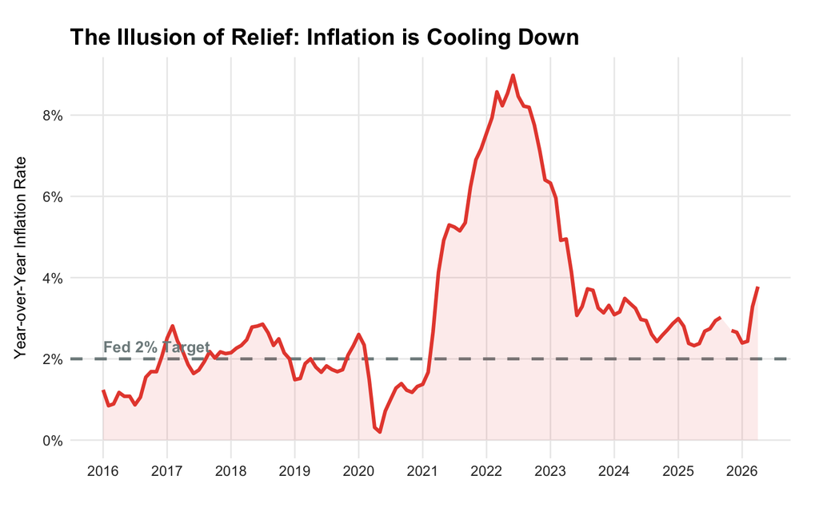

## Part 3: How We Feel Inflation

Let’s zoom in on the lowest 20% of earners to start seeing how people in different income brackets feel inflation by how much they have to spend on necessities.

When we reveal their mean income, the severity of the crisis becomes clear. This group faces a harsh deficit, they are forced to spend thousands of dollars more than they earn, taking on debt just to afford housing and food.

For the middle 20%, we finally see a surplus begin to form, allowing for a modest amount of savings and discretionary spending.

By the fourth bracket, discretionary income expands significantly. They are largely shielded from spikes in the cost of gas or groceries.

And for the highest 20% of earners, basic survival necessities represent only a tiny fraction of a massive income pool.

When we clear the numbers and zoom out to view the entire economy, the reality of the wealth gap becomes undeniable. The bottom end is structurally squeezed, while the top has a massive surplus to invest.

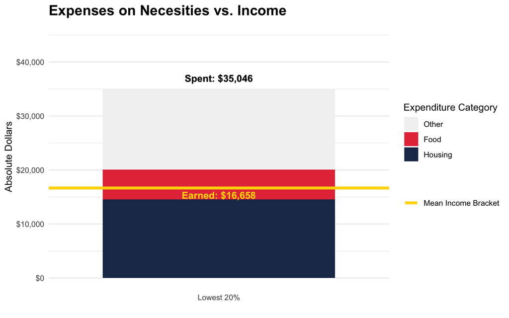

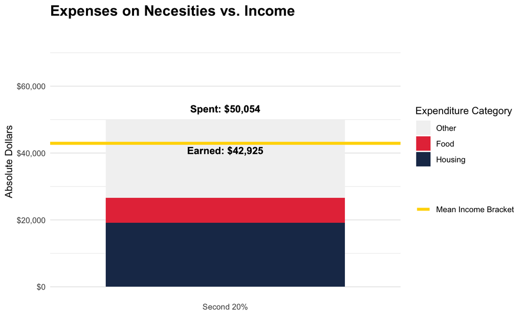

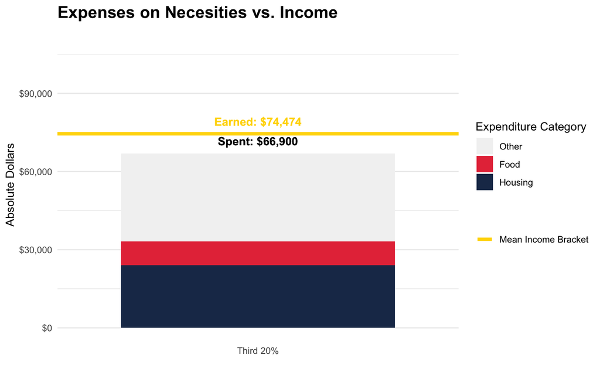

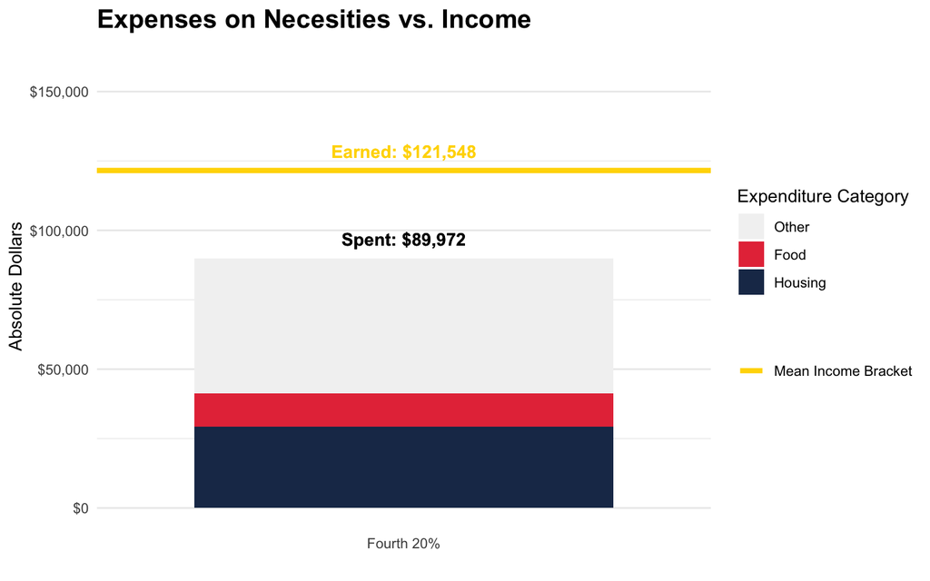

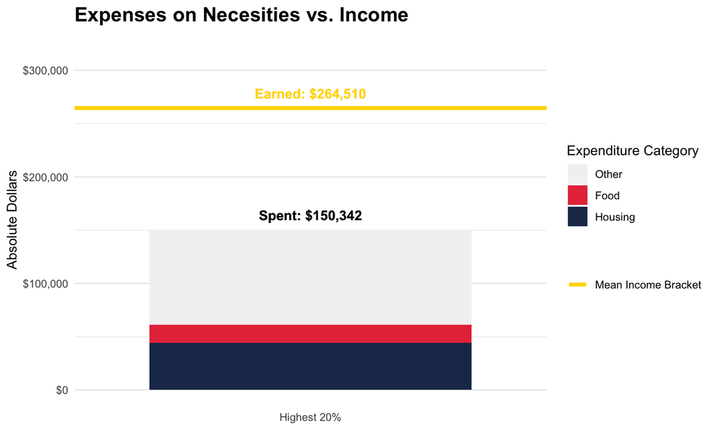

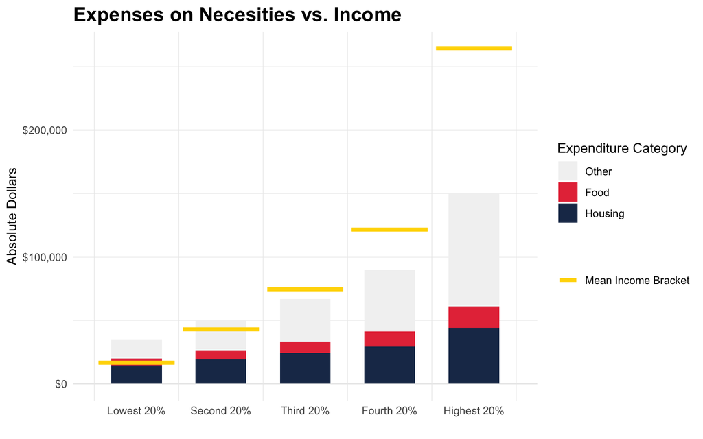

## Part 4: The Wealth Gap

When we combine these booming stock and asset prices with overwhelming costs on necessities, we get a “K-Shaped” economy.

But the most alarming reality belongs to the bottom 50% of Americans.

Because the bottom 50% must spend most their entire budget to survive, they cannot invest. Therefore, the wealth of the bottom 50% flatlines entirely against the bottom of the axis. Two Americas, living in the same country, experiencing entirely different economies.

Hover over the lines to explore the exact wealth gap.

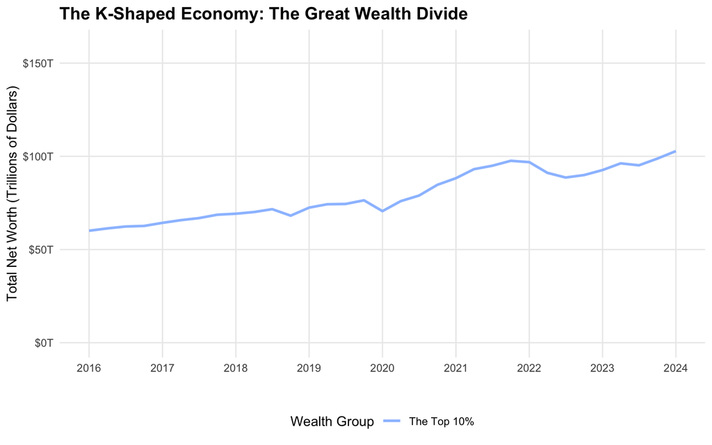

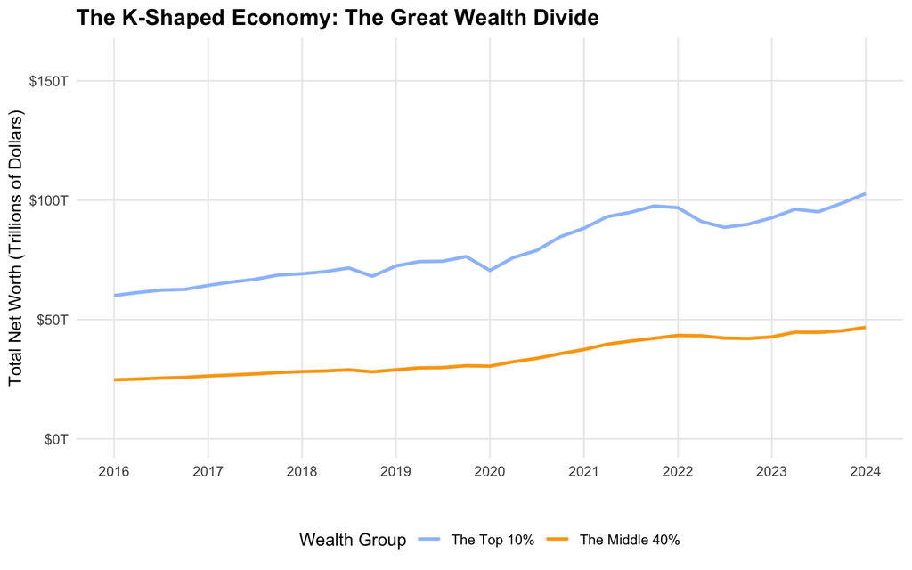

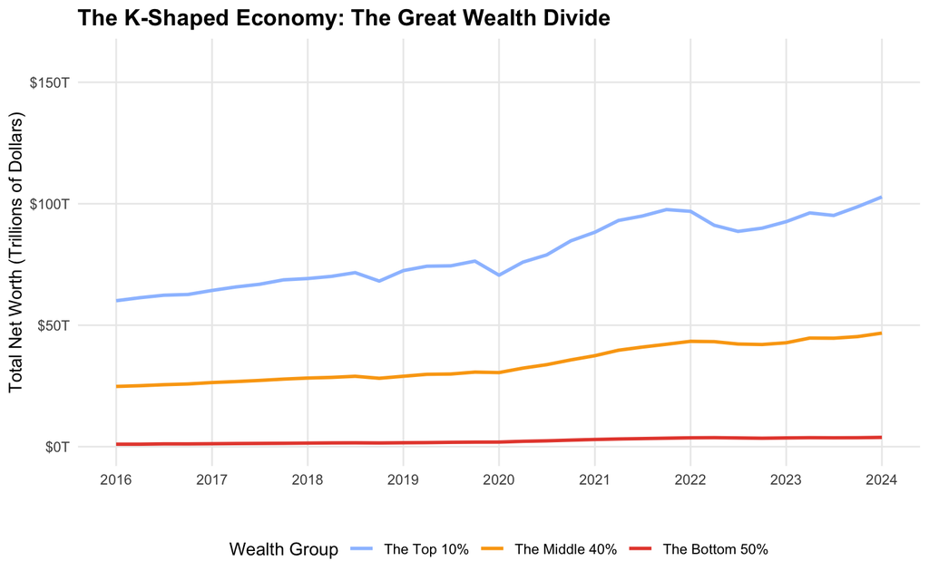

[interactive chart not shown]

## Links

Data Sources and Site Details